# 3: Logistic regression

*Describe the work you have done this week and summarize your learning.*

- Describe your work and results clearly.
- Assume the reader has an introductory course level understanding of writing and reading R code as well as statistical methods.
- Assume the reader has no previous knowledge of your data or the more advanced methods you are using.

```r
date()
```

```
## [1] "Fri Nov 18 09:52:30 2022"
```

Libraries used:

```r
#install.packages("vtable")
library(vtable)
library(tidyverse)
#install.packages("sjPlot")
library(sjPlot)
```

Let’s read in the data. I read in the data from the url just in case, even though I think my data wrangling was successful.

```r
data_chap3 <- read.table("https://raw.githubusercontent.com/KimmoVehkalahti/Helsinki-Open-Data-Science/master/datasets/alc.csv", sep = ",", header = TRUE)
```

Let’s print out variable names.

```r
colnames(data_chap3)
```

```
##  [1] "school"     "sex"        "age"        "address"    "famsize"
##  [6] "Pstatus"    "Medu"       "Fedu"       "Mjob"       "Fjob"
## [11] "reason"     "guardian"   "traveltime" "studytime"  "schoolsup"
## [16] "famsup"     "activities" "nursery"    "higher"     "internet"
## [21] "romantic"   "famrel"     "freetime"   "goout"      "Dalc"
## [26] "Walc"       "health"     "failures"   "paid"       "absences"
## [31] "G1"         "G2"         "G3"         "alc_use"    "high_use"
```

The data set contains 35 variables. 33 of them were from UCI Machine Learning Repository, Student Performance Data (incl. Alcohol consumption). 2 variables, “alc_use” and “high_use” are created. Variable “alc_use” is created by taking average from “Dalc” (weekday alcohol use) and “Walc” (weekend alcohol use). Variable ‘high_use’ is TRUE if ‘alc_use’ is higher than 2 and FALSE otherwise.

```r
str(data_chap3)
```

```
## 'data.frame':    370 obs. of  35 variables:
##  $ school    : chr  "GP" "GP" "GP" "GP" ...
##  $ sex       : chr  "F" "F" "F" "F" ...
##  $ age       : int  18 17 15 15 16 16 16 17 15 15 ...
##  $ address   : chr  "U" "U" "U" "U" ...
##  $ famsize   : chr  "GT3" "GT3" "LE3" "GT3" ...
##  $ Pstatus   : chr  "A" "T" "T" "T" ...
##  $ Medu      : int  4 1 1 4 3 4 2 4 3 3 ...
##  $ Fedu      : int  4 1 1 2 3 3 2 4 2 4 ...
##  $ Mjob      : chr  "at_home" "at_home" "at_home" "health" ...
##  $ Fjob      : chr  "teacher" "other" "other" "services" ...
##  $ reason    : chr  "course" "course" "other" "home" ...
##  $ guardian  : chr  "mother" "father" "mother" "mother" ...
##  $ traveltime: int  2 1 1 1 1 1 1 2 1 1 ...
##  $ studytime : int  2 2 2 3 2 2 2 2 2 2 ...
```

[output cut: 21 more lines]

```r
dim(data_chap3)
```

```
## [1] 370  35
```

The data set contains 370 observations. The data set contains multiple character and integer variables, and one numerical and one logical variable. The variables and their possible values (from https://archive.ics.uci.edu/ml/datasets/Student+Performance):

Attributes for both student-mat.csv (Math course) and student-por.csv (Portuguese language course) datasets:

1 school - student’s school (binary: ‘GP’ - Gabriel Pereira or ‘MS’ - Mousinho da Silveira)

2 sex - student’s sex (binary: ‘F’ - female or ‘M’ - male)

3 age - student’s age (numeric: from 15 to 22)

4 address - student’s home address type (binary: ‘U’ - urban or ‘R’ - rural)

5 famsize - family size (binary: ‘LE3’ - less or equal to 3 or ‘GT3’ - greater than 3)

6 Pstatus - parent’s cohabitation status (binary: ‘T’ - living together or ‘A’ - apart)

7 Medu - mother’s education (numeric: 0 - none, 1 - primary education (4th grade), 2 - 5th to 9th grade, 3 - secondary education or 4 - higher education)

8 Fedu - father’s education (numeric: 0 - none, 1 - primary education (4th grade), 2 - 5th to 9th grade, 3 - secondary education or 4 - higher education)

9 Mjob - mother’s job (nominal: ‘teacher’, ‘health’ care related, civil ‘services’ (e.g. administrative or police), ‘at_home’ or ‘other’)

10 Fjob - father’s job (nominal: ‘teacher’, ‘health’ care related, civil ‘services’ (e.g. administrative or police), ‘at_home’ or ‘other’)

11 reason - reason to choose this school (nominal: close to ‘home’, school ‘reputation’, ‘course’ preference or ‘other’)

12 guardian - student’s guardian (nominal: ‘mother’, ‘father’ or ‘other’)

13 traveltime - home to school travel time (numeric: 1 - <15 min., 2 - 15 to 30 min., 3 - 30 min. to 1 hour, or 4 - >1 hour)

14 studytime - weekly study time (numeric: 1 - <2 hours, 2 - 2 to 5 hours, 3 - 5 to 10 hours, or 4 - >10 hours)

15 failures - number of past class failures (numeric: n if 1<=n<3, else 4)

16 schoolsup - extra educational support (binary: yes or no)

17 famsup - family educational support (binary: yes or no)

18 paid - extra paid classes within the course subject (Math or Portuguese) (binary: yes or no)

19 activities - extra-curricular activities (binary: yes or no)

20 nursery - attended nursery school (binary: yes or no)

21 higher - wants to take higher education (binary: yes or no)

22 internet - Internet access at home (binary: yes or no)

23 romantic - with a romantic relationship (binary: yes or no)

24 famrel - quality of family relationships (numeric: from 1 - very bad to 5 - excellent)

25 freetime - free time after school (numeric: from 1 - very low to 5 - very high)

26 goout - going out with friends (numeric: from 1 - very low to 5 - very high)

27 Dalc - workday alcohol consumption (numeric: from 1 - very low to 5 - very high)

28 Walc - weekend alcohol consumption (numeric: from 1 - very low to 5 - very high)

29 health - current health status (numeric: from 1 - very bad to 5 - very good)

30 absences - number of school absences (numeric: from 0 to 93)

These grades are related with the course subject, Math or Portuguese:

31 G1 - first period grade (numeric: from 0 to 20)

31 G2 - second period grade (numeric: from 0 to 20)

32 G3 - final grade (numeric: from 0 to 20, output target)

The data set also includes the created variables “alc_use” and “high_use” which were described above.

Let’s use vtable-package and its st()-function to summarize data (I learned about this package in this course). It will print a summary statistics table (also to the Viewer in RStudio).

```r
st(data_chap3)
```

Summary Statistics

| Variable | N | Mean | Std. Dev. | Min | Pctl. 25 | Pctl. 75 | Max |
| --- | --- | --- | --- | --- | --- | --- | --- |
| school | 370 |  |  |  |  |  |  |
| … GP | 331 | 89.5% |  |  |  |  |  |
| … MS | 39 | 10.5% |  |  |  |  |  |
| sex | 370 |  |  |  |  |  |  |
| … F | 195 | 52.7% |  |  |  |  |  |
| … M | 175 | 47.3% |  |  |  |  |  |
| age | 370 | 16.576 | 1.181 | 15 | 16 | 17 | 22 |
| address | 370 |  |  |  |  |  |  |
| … R | 81 | 21.9% |  |  |  |  |  |
| … U | 289 | 78.1% |  |  |  |  |  |
| famsize | 370 |  |  |  |  |  |  |
| … GT3 | 266 | 71.9% |  |  |  |  |  |
| … LE3 | 104 | 28.1% |  |  |  |  |  |
| Pstatus | 370 |  |  |  |  |  |  |
| … A | 38 | 10.3% |  |  |  |  |  |
| … T | 332 | 89.7% |  |  |  |  |  |
| Medu | 370 | 2.8 | 1.084 | 0 | 2 | 4 | 4 |
| Fedu | 370 | 2.557 | 1.086 | 0 | 2 | 3.75 | 4 |
| Mjob | 370 |  |  |  |  |  |  |
| … at_home | 53 | 14.3% |  |  |  |  |  |
| … health | 33 | 8.9% |  |  |  |  |  |
| … other | 134 | 36.2% |  |  |  |  |  |
| … services | 93 | 25.1% |  |  |  |  |  |
| … teacher | 57 | 15.4% |  |  |  |  |  |
| Fjob | 370 |  |  |  |  |  |  |
| … at_home | 16 | 4.3% |  |  |  |  |  |
| … health | 17 | 4.6% |  |  |  |  |  |
| … other | 205 | 55.4% |  |  |  |  |  |
| … services | 103 | 27.8% |  |  |  |  |  |
| … teacher | 29 | 7.8% |  |  |  |  |  |
| reason | 370 |  |  |  |  |  |  |
| … course | 135 | 36.5% |  |  |  |  |  |
| … home | 103 | 27.8% |  |  |  |  |  |
| … other | 34 | 9.2% |  |  |  |  |  |
| … reputation | 98 | 26.5% |  |  |  |  |  |
| guardian | 370 |  |  |  |  |  |  |
| … father | 88 | 23.8% |  |  |  |  |  |
| … mother | 266 | 71.9% |  |  |  |  |  |
| … other | 16 | 4.3% |  |  |  |  |  |
| traveltime | 370 | 1.446 | 0.701 | 1 | 1 | 2 | 4 |
| studytime | 370 | 2.043 | 0.848 | 1 | 1 | 2 | 4 |
| schoolsup | 370 |  |  |  |  |  |  |
| … no | 321 | 86.8% |  |  |  |  |  |
| … yes | 49 | 13.2% |  |  |  |  |  |
| famsup | 370 |  |  |  |  |  |  |
| … no | 139 | 37.6% |  |  |  |  |  |
| … yes | 231 | 62.4% |  |  |  |  |  |
| activities | 370 |  |  |  |  |  |  |
| … no | 179 | 48.4% |  |  |  |  |  |
| … yes | 191 | 51.6% |  |  |  |  |  |
| nursery | 370 |  |  |  |  |  |  |
| … no | 72 | 19.5% |  |  |  |  |  |
| … yes | 298 | 80.5% |  |  |  |  |  |
| higher | 370 |  |  |  |  |  |  |
| … no | 16 | 4.3% |  |  |  |  |  |
| … yes | 354 | 95.7% |  |  |  |  |  |
| internet | 370 |  |  |  |  |  |  |
| … no | 57 | 15.4% |  |  |  |  |  |
| … yes | 313 | 84.6% |  |  |  |  |  |
| romantic | 370 |  |  |  |  |  |  |
| … no | 251 | 67.8% |  |  |  |  |  |
| … yes | 119 | 32.2% |  |  |  |  |  |
| famrel | 370 | 3.935 | 0.911 | 1 | 4 | 5 | 5 |
| freetime | 370 | 3.224 | 0.986 | 1 | 3 | 4 | 5 |
| goout | 370 | 3.116 | 1.129 | 1 | 2 | 4 | 5 |
| Dalc | 370 | 1.484 | 0.896 | 1 | 1 | 2 | 5 |
| Walc | 370 | 2.295 | 1.291 | 1 | 1 | 3 | 5 |
| health | 370 | 3.562 | 1.408 | 1 | 3 | 5 | 5 |
| failures | 370 | 0.189 | 0.558 | 0 | 0 | 0 | 3 |
| paid | 370 |  |  |  |  |  |  |
| … no | 196 | 53% |  |  |  |  |  |
| … yes | 174 | 47% |  |  |  |  |  |
| absences | 370 | 4.511 | 5.504 | 0 | 1 | 6 | 45 |
| G1 | 370 | 11.522 | 2.702 | 2 | 10 | 14 | 18 |
| G2 | 370 | 11.503 | 2.813 | 4 | 10 | 14 | 18 |
| G3 | 370 | 11.516 | 3.288 | 0 | 10 | 14 | 18 |
| alc_use | 370 | 1.889 | 0.998 | 1 | 1 | 2.5 | 5 |
| high_use | 370 |  |  |  |  |  |  |
| … No | 259 | 70% |  |  |  |  |  |
| … Yes | 111 | 30% |  |  |  |  |  |

The mean age of respondents is 16.576 with a standard deviation of 1.181. There are 52,7% (n=195) females and 47.3% (n=175) males. 89.5% of the respondents are from ‘GP’ - Gabriel Pereira schooland 10.5% are from ‘MS’ - Mousinho da Silveira.

## Four variables and their relationships to high alcohol use

Let’s choose four variable and analyze their relationships with alcohol use.

I choose these variables:

**“absences”** - number of school absences (numeric: from 0 to 93)

I would guess that more absences are connected to higher alcohol use.

**“famrel”** - quality of family relationships (numeric: from 1 - very bad to 5 - excellent)

I make a educated guess that the worse the quality of family relationships, the more probable higher alcohol use is.

**“Medu”** - mother’s education (numeric: 0 - none, 1 - primary education (4th grade), 2 - 5th to 9th grade, 3 - secondary education or 4 - higher education)

My hypothesis is that the lower the mother’s education, the more probably respondent has high alcohol use.

**G3** - final grade (numeric: from 0 to 20, output target)

I would expect that those with high alcohol use get worse grades.

Let’s explore these variables more. Let’s first take numerical summaries.

```r
summary(data_chap3$absences)
```

```
##    Min. 1st Qu.  Median    Mean 3rd Qu.    Max.
##   0.000   1.000   3.000   4.511   6.000  45.000
```

```r
summary(data_chap3$Medu)
```

```
##    Min. 1st Qu.  Median    Mean 3rd Qu.    Max.
##     0.0     2.0     3.0     2.8     4.0     4.0
```

```r
summary(data_chap3$famrel)
```

```
##    Min. 1st Qu.  Median    Mean 3rd Qu.    Max.
##   1.000   4.000   4.000   3.935   5.000   5.000
```

```r
summary(data_chap3$G3)
```

```
##    Min. 1st Qu.  Median    Mean 3rd Qu.    Max.
##    0.00   10.00   12.00   11.52   14.00   18.00
```

Mean number of absences is 4.511 with the maximum of 45.

Mean mother’s education level is 2.8 with median of 3 (secondary education).

Mean of family relations is 3.935.

Mean grade is 11.52 out of 20 maximum points. No one has gotten the maximum points.

Let’s use multiplot function that is supposed to be in ggplot. It for some reason requires one to first run this code (I learned this also from someone in this course, thank you very much):

```r
multiplot <- function(..., plotlist = NULL, file, cols = 1, layout = NULL) {
  require(grid)

  plots <- c(list(...), plotlist)

  numPlots = length(plots)

  if (is.null(layout)) {
    layout <- matrix(seq(1, cols * ceiling(numPlots/cols)),
                 ncol = cols, nrow = ceiling(numPlots/cols))
}

if (numPlots == 1) {
print(plots[[1]])

} else {
grid.newpage()
pushViewport(viewport(layout = grid.layout(nrow(layout), ncol(layout))))

for (i in 1:numPlots) {
  matchidx <- as.data.frame(which(layout == i, arr.ind = TRUE))

  print(plots[[i]], vp = viewport(layout.pos.row = matchidx$row,
                                  layout.pos.col = matchidx$col))
 }
}
 }
```

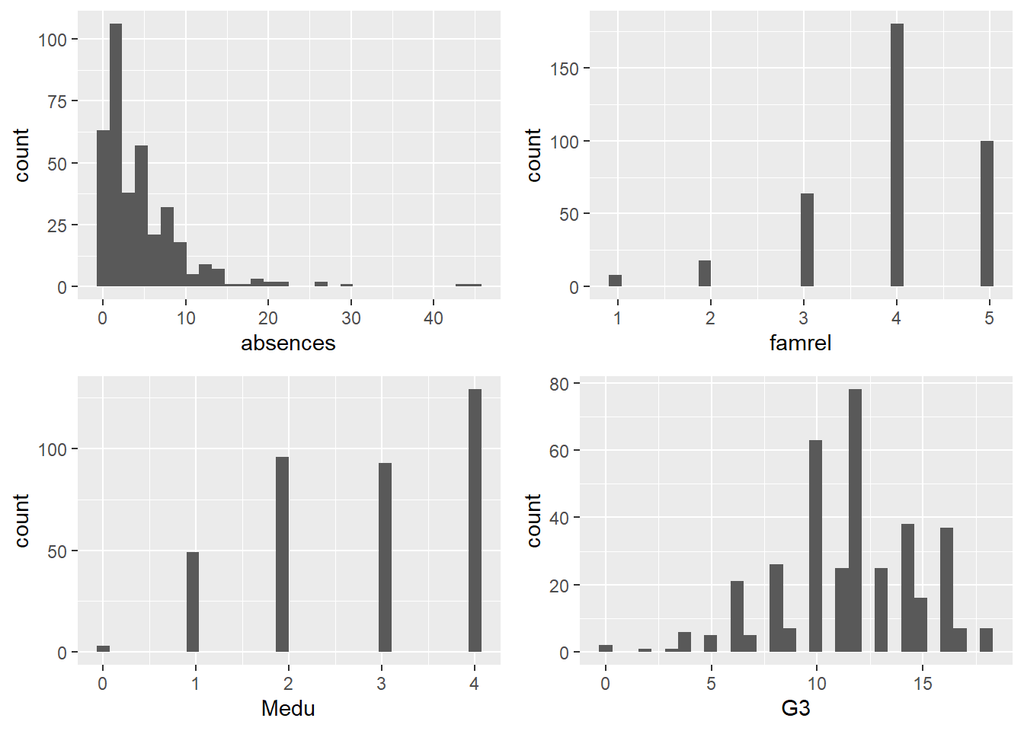

```r
p1 <- ggplot(data_chap3, aes(x=absences)) +
  geom_histogram()

p2 <- ggplot(data_chap3, aes(x=Medu)) +
  geom_histogram()

p3 <- ggplot(data_chap3, aes(x=famrel)) +
  geom_histogram()

p4 <- ggplot(data_chap3, aes(x=G3)) +
  geom_histogram()

multiplot(p1,p2,p3,p4, cols = 2)
```

Absences plot is right skewed with most of the absence numbers being under 10. I am not sure if fam rel and medu plots can be said to be skewed, but they would be left-skewed. The same goes for G3, final grades plot.

Let’s try to use cross-tabulation from sjPlot package, following this https://bookdown.org/wadetroberts/r-you-ready-for-r/cross-tabulation.html. I have really never used that package, so this is a nice learning opportunity.

Absences

```r
sjPlot::tab_xtab(var.row = data_chap3$absences, var.col = data_chap3$high_use, title = "Cross-tabulation: Absences and high alcohol use", show.row.prc = TRUE)
```

Cross-tabulation: Absences and high alcohol use

| absences | high_use |  | Total |  |
| --- | --- | --- | --- | --- |
|  | FALSE | TRUE |  |  |
| 0 | 50 79.4 % | 13 20.6 % |  | 63 100 % |
| 1 | 37 74 % | 13 26 % | 50 100 % |  |
| 2 | 40 71.4 % | 16 28.6 % | 56 100 % |  |
| 3 | 31 81.6 % | 7 18.4 % | 38 100 % |  |
| 4 | 24 68.6 % | 11 31.4 % | 35 100 % |  |
| 5 | 16 72.7 % | 6 27.3 % | 22 100 % |  |
| 6 | 16 76.2 % | 5 23.8 % | 21 100 % |  |
| 7 | 9 75 % | 3 25 % | 12 100 % |  |
| 8 | 14 70 % | 6 30 % | 20 100 % |  |
| 9 | 5 45.5 % | 6 54.5 % | 11 100 % |  |
| 10 | 5 71.4 % | 2 28.6 % | 7 100 % |  |
| 11 | 2 40 % | 3 60 % | 5 100 % |  |
| 12 | 3 42.9 % | 4 57.1 % | 7 100 % |  |
| 13 | 1 50 % | 1 50 % | 2 100 % |  |
| 14 | 1 14.3 % | 6 85.7 % | 7 100 % |  |
| 16 | 0 0 % | 1 100 % | 1 100 % |  |
| 17 | 0 0 % | 1 100 % | 1 100 % |  |
| 18 | 1 50 % | 1 50 % | 2 100 % |  |
| 19 | 0 0 % | 1 100 % | 1 100 % |  |
| 20 | 2 100 % | 0 0 % | 2 100 % |  |
| 21 | 1 50 % | 1 50 % | 2 100 % |  |
| 26 | 0 0 % | 1 100 % | 1 100 % |  |
| 27 | 0 0 % | 1 100 % | 1 100 % |  |
| 29 | 0 0 % | 1 100 % | 1 100 % |  |
| 44 | 0 0 % | 1 100 % | 1 100 % |  |
| 45 | 1 100 % | 0 0 % | 1 100 % |  |
| Total | 259 70 % | 111 30 % | 370 100 % |  |

Family relationships

```r
sjPlot::tab_xtab(var.row = data_chap3$famrel, var.col = data_chap3$high_use, title = "Cross-tabulation: Family relationship and high alcohol use", show.row.prc = TRUE)
```

Cross-tabulation: Family relationship and high alcohol use

| famrel | high_use |  | Total |  |
| --- | --- | --- | --- | --- |
|  | FALSE | TRUE |  |  |
| 1 | 6 75 % | 2 25 % |  | 8 100 % |
| 2 | 9 50 % | 9 50 % | 18 100 % |  |
| 3 | 39 60.9 % | 25 39.1 % | 64 100 % |  |
| 4 | 128 71.1 % | 52 28.9 % | 180 100 % |  |
| 5 | 77 77 % | 23 23 % | 100 100 % |  |
| Total | 259 70 % | 111 30 % | 370 100 % |  |

Mother’s education

```r
sjPlot::tab_xtab(var.row = data_chap3$Medu, var.col = data_chap3$high_use, title = "Cross-tabulation: Mother's education and high alcohol use", show.row.prc = TRUE)
```

Cross-tabulation: Mother’s education and high alcohol use

| Medu | high_use |  | Total |  |
| --- | --- | --- | --- | --- |
|  | FALSE | TRUE |  |  |
| 0 | 1 33.3 % | 2 66.7 % |  | 3 100 % |
| 1 | 31 63.3 % | 18 36.7 % | 49 100 % |  |
| 2 | 78 81.2 % | 18 18.8 % | 96 100 % |  |
| 3 | 57 61.3 % | 36 38.7 % | 93 100 % |  |
| 4 | 92 71.3 % | 37 28.7 % | 129 100 % |  |
| Total | 259 70 % | 111 30 % | 370 100 % |  |

G3

```r
sjPlot::tab_xtab(var.row = data_chap3$G3, var.col = data_chap3$high_use, title = "Cross-tabulation: Final grade and high alcohol use", show.row.prc = TRUE)
```

Cross-tabulation: Final grade and high alcohol use

| G3 | high_use |  | Total |  |
| --- | --- | --- | --- | --- |
|  | FALSE | TRUE |  |  |
| 0 | 1 50 % | 1 50 % |  | 2 100 % |
| 2 | 0 0 % | 1 100 % | 1 100 % |  |
| 3 | 1 100 % | 0 0 % | 1 100 % |  |
| 4 | 5 83.3 % | 1 16.7 % | 6 100 % |  |
| 5 | 3 60 % | 2 40 % | 5 100 % |  |
| 6 | 15 71.4 % | 6 28.6 % | 21 100 % |  |
| 7 | 3 60 % | 2 40 % | 5 100 % |  |
| 8 | 18 69.2 % | 8 30.8 % | 26 100 % |  |
| 9 | 3 42.9 % | 4 57.1 % | 7 100 % |  |
| 10 | 38 60.3 % | 25 39.7 % | 63 100 % |  |
| 11 | 16 64 % | 9 36 % | 25 100 % |  |
| 12 | 51 65.4 % | 27 34.6 % | 78 100 % |  |
| 13 | 18 72 % | 7 28 % | 25 100 % |  |
| 14 | 31 81.6 % | 7 18.4 % | 38 100 % |  |
| 15 | 15 93.8 % | 1 6.2 % | 16 100 % |  |
| 16 | 29 78.4 % | 8 21.6 % | 37 100 % |  |
| 17 | 5 71.4 % | 2 28.6 % | 7 100 % |  |
| 18 | 7 100 % | 0 0 % | 7 100 % |  |
| Total | 259 70 % | 111 30 % | 370 100 % |  |